# limiares

#### Allegro

0.1 [1] “

"

#### Evolução dos desenvolvedores ao longo do tempo

( janela 24 semanas, iteracao de 4 semanas) [1] “

"

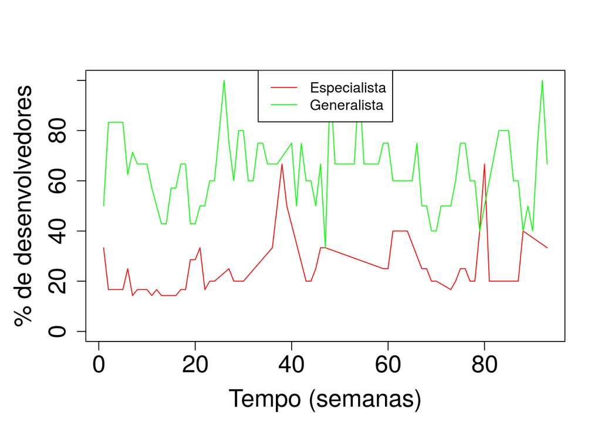

|  | esp | gen |
| --- | --- | --- |
| twosided | 0.0001828 | 0.3597983 |
| greater | 0.0000914 | 0.8201008 |
| less | 0.9999086 | 0.1798992 |

#### Allegro

0.2 [1] “

"

#### Evolução dos desenvolvedores ao longo do tempo

( janela 24 semanas, iteracao de 4 semanas) [1] “

"

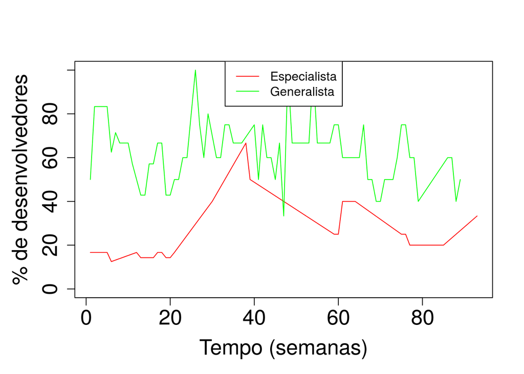

|  | esp | gen |
| --- | --- | --- |
| twosided | 0.0054126 | 0.0524892 |
| greater | 0.0027063 | 0.9737554 |
| less | 0.9972937 | 0.0262446 |

#### Allegro

0.3 [1] “

"

#### Evolução dos desenvolvedores ao longo do tempo

( janela 24 semanas, iteracao de 4 semanas) [1] “

"

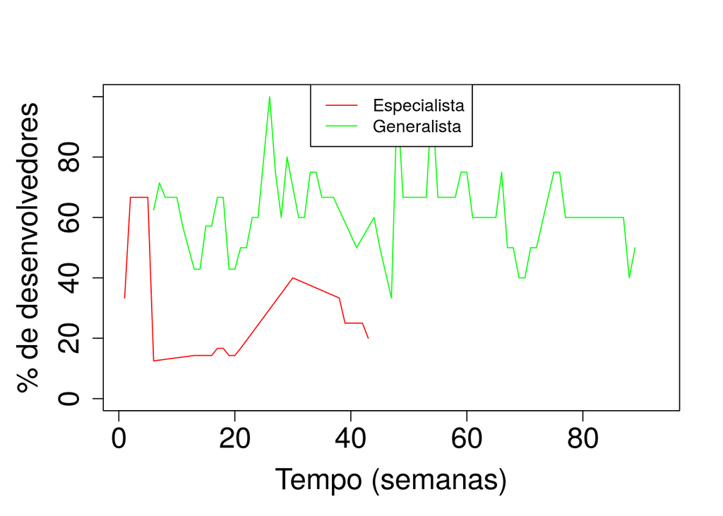

|  | esp | gen |
| --- | --- | --- |
| twosided | 0.8774477 | 0.5499886 |
| greater | 0.5612761 | 0.7250057 |
| less | 0.4387239 | 0.2749943 |

#### Allegro

0.4 [1] “

"

#### Evolução dos desenvolvedores ao longo do tempo

( janela 24 semanas, iteracao de 4 semanas) [1] “

"

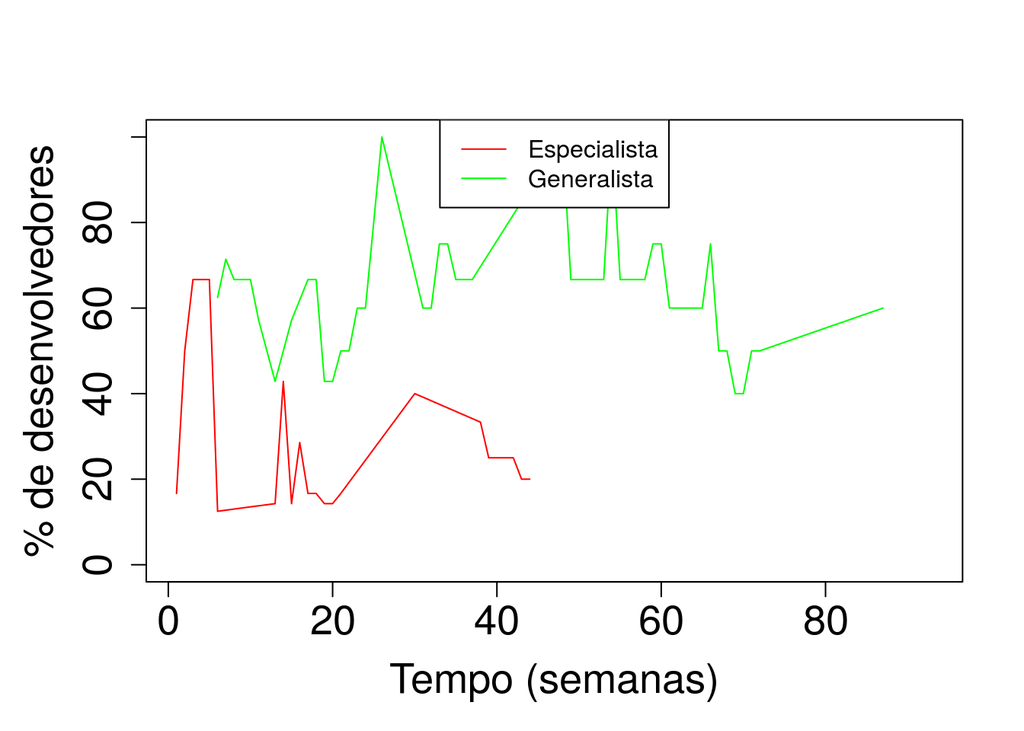

|  | esp | gen |
| --- | --- | --- |
| twosided | 0.5216911 | 0.4517602 |
| greater | 0.7391545 | 0.7741199 |
| less | 0.2608455 | 0.2258801 |

#### Allegro

0.5 [1] “

"

#### Evolução dos desenvolvedores ao longo do tempo

( janela 24 semanas, iteracao de 4 semanas) [1] “

"

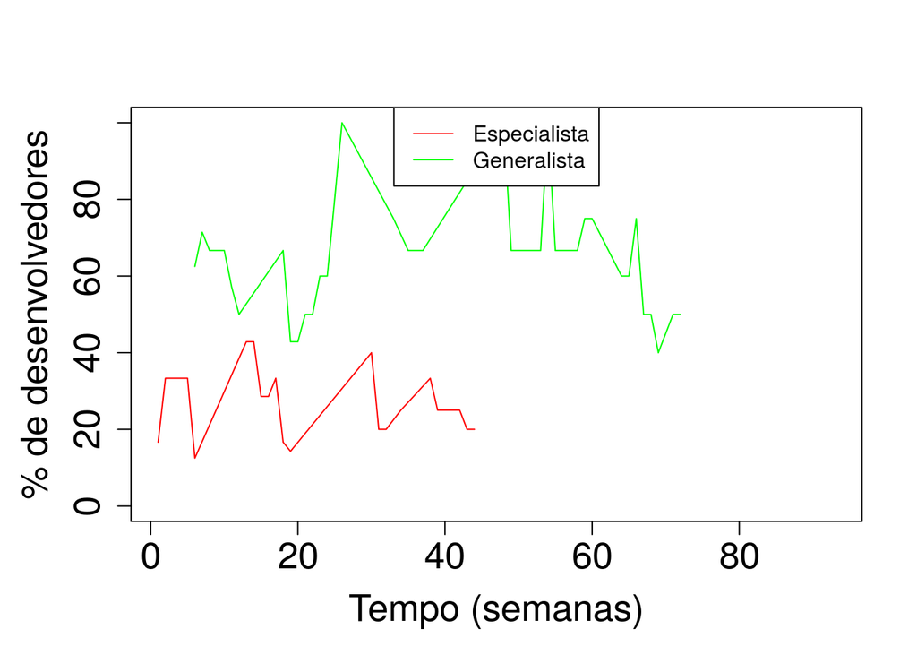

|  | esp | gen |
| --- | --- | --- |
| twosided | 0.1501048 | 0.7797702 |
| greater | 0.9249476 | 0.6101149 |
| less | 0.0750524 | 0.3898851 |

#### SDL

0.1 [1] “

"

#### Evolução dos desenvolvedores ao longo do tempo

( janela 24 semanas, iteracao de 4 semanas) [1] “

"

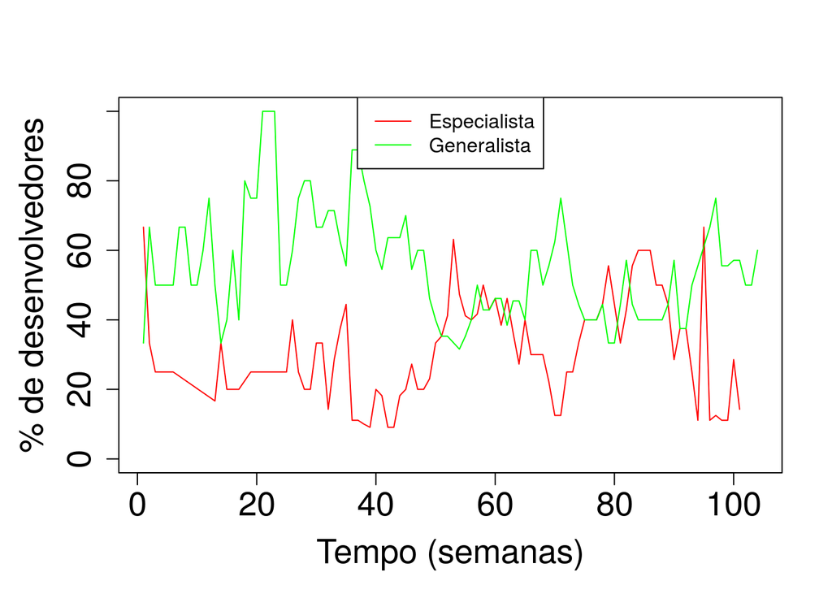

|  | esp | gen |
| --- | --- | --- |
| twosided | 0.0178328 | 0.0013270 |
| greater | 0.0089164 | 0.9993365 |
| less | 0.9910836 | 0.0006635 |

#### SDL

0.2 [1] “

"

#### Evolução dos desenvolvedores ao longo do tempo

( janela 24 semanas, iteracao de 4 semanas) [1] “

"

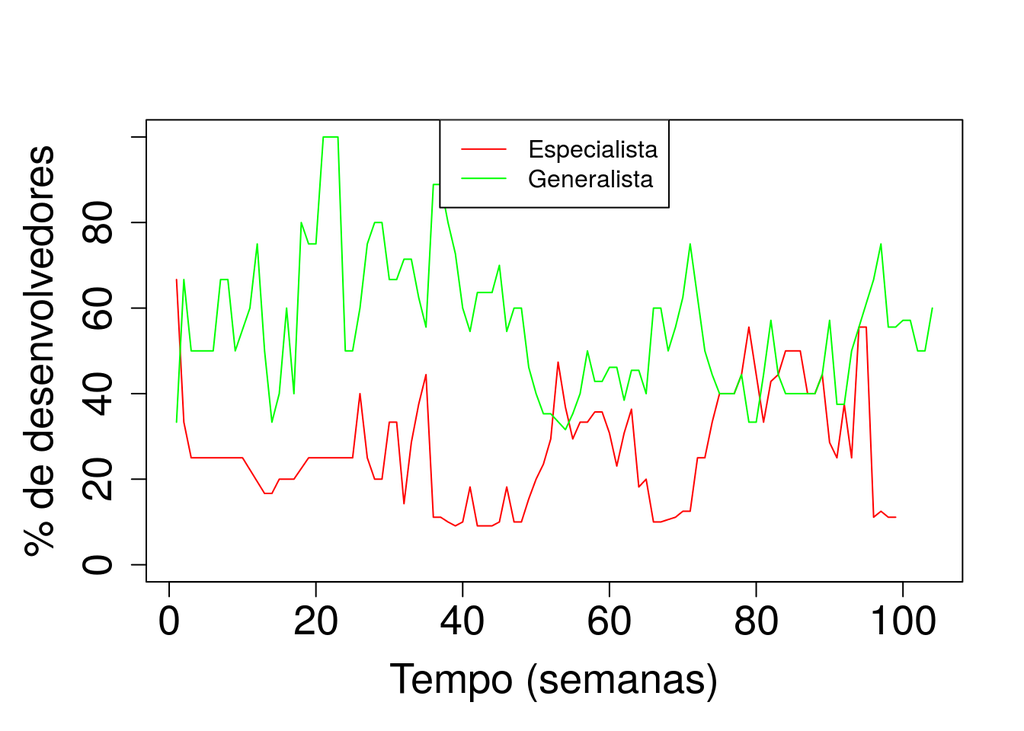

|  | esp | gen |
| --- | --- | --- |
| twosided | 0.0093032 | 0.0007231 |
| greater | 0.0046516 | 0.9996384 |
| less | 0.9953484 | 0.0003616 |

#### SDL

0.3 [1] “

"

#### Evolução dos desenvolvedores ao longo do tempo

( janela 24 semanas, iteracao de 4 semanas) [1] “

"

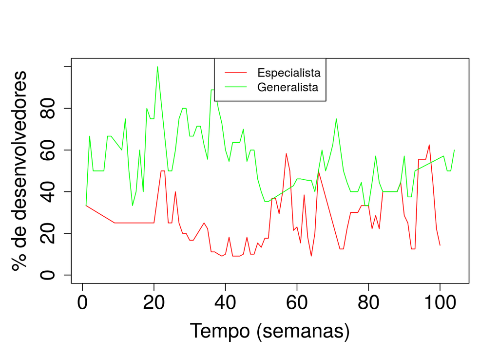

|  | esp | gen |
| --- | --- | --- |
| twosided | 0.0096628 | 0.0000714 |
| greater | 0.0048314 | 0.9999643 |
| less | 0.9951686 | 0.0000357 |

#### SDL

0.4 [1] “

"

#### Evolução dos desenvolvedores ao longo do tempo

( janela 24 semanas, iteracao de 4 semanas) [1] “

"

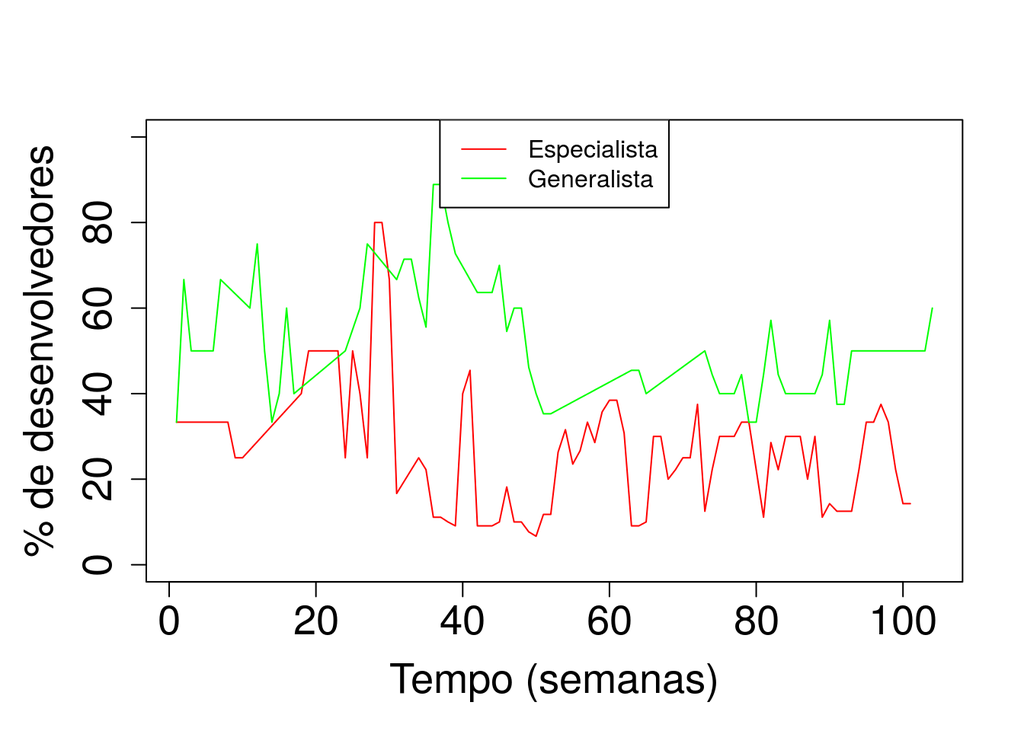

|  | esp | gen |
| --- | --- | --- |
| twosided | 0.1198491 | 0.0019131 |
| greater | 0.9400755 | 0.9990435 |
| less | 0.0599245 | 0.0009565 |

#### SDL

0.5 [1] “

"

#### Evolução dos desenvolvedores ao longo do tempo

( janela 24 semanas, iteracao de 4 semanas) [1] “

"

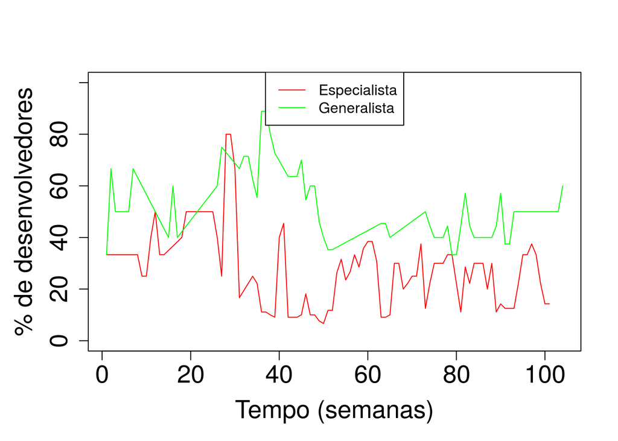

|  | esp | gen |
| --- | --- | --- |
| twosided | 0.0212855 | 0.0008407 |
| greater | 0.9893573 | 0.9995797 |
| less | 0.0106427 | 0.0004203 |

#### SFML

0.1 [1] “

"

#### Evolução dos desenvolvedores ao longo do tempo

( janela 24 semanas, iteracao de 4 semanas) [1] “

"

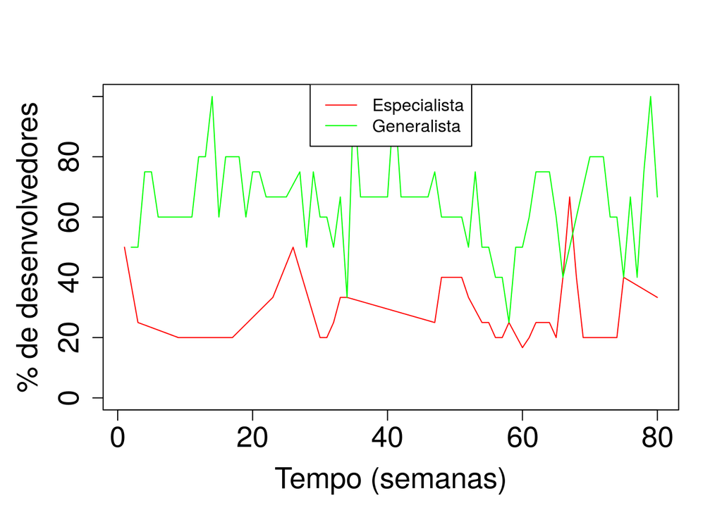

|  | esp | gen |
| --- | --- | --- |
| twosided | 0.6277354 | 0.277890 |
| greater | 0.3138677 | 0.861055 |
| less | 0.6861323 | 0.138945 |

#### SFML

0.2 [1] “

"

#### Evolução dos desenvolvedores ao longo do tempo

( janela 24 semanas, iteracao de 4 semanas) [1] “

"

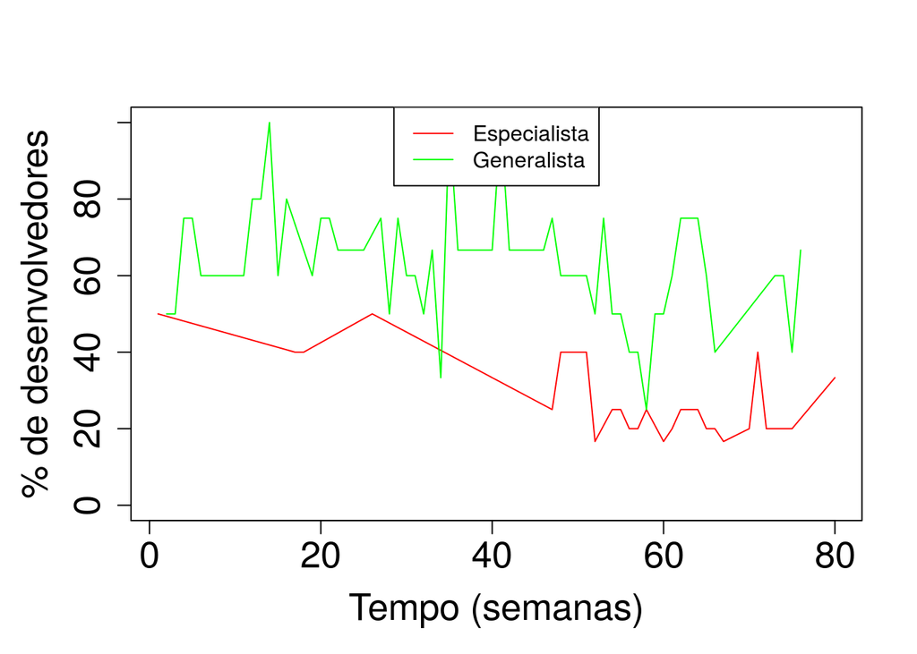

|  | esp | gen |
| --- | --- | --- |
| twosided | 0.0023710 | 0.0403835 |
| greater | 0.9988145 | 0.9798083 |
| less | 0.0011855 | 0.0201917 |

#### SFML

0.3 [1] “

"

#### Evolução dos desenvolvedores ao longo do tempo

( janela 24 semanas, iteracao de 4 semanas) [1] “

"

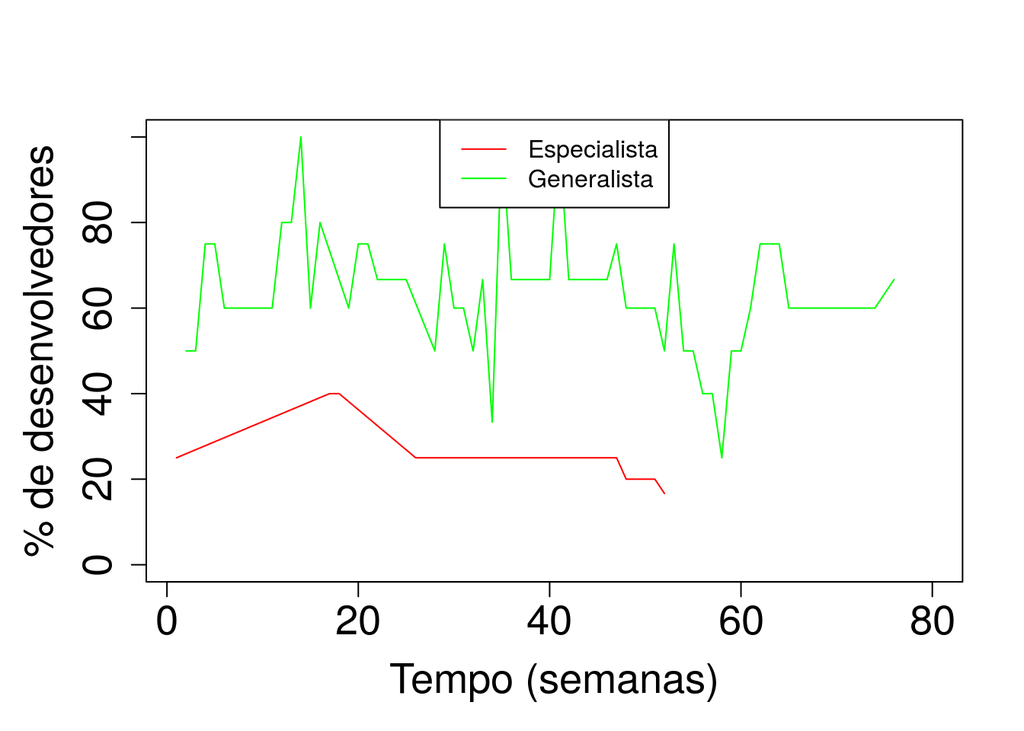

|  | esp | gen |
| --- | --- | --- |
| twosided | 0.0022493 | 0.1562797 |
| greater | 0.9988754 | 0.9218601 |
| less | 0.0011246 | 0.0781399 |

#### SFML

0.4 [1] “

"

#### Evolução dos desenvolvedores ao longo do tempo

( janela 24 semanas, iteracao de 4 semanas) [1] “

"

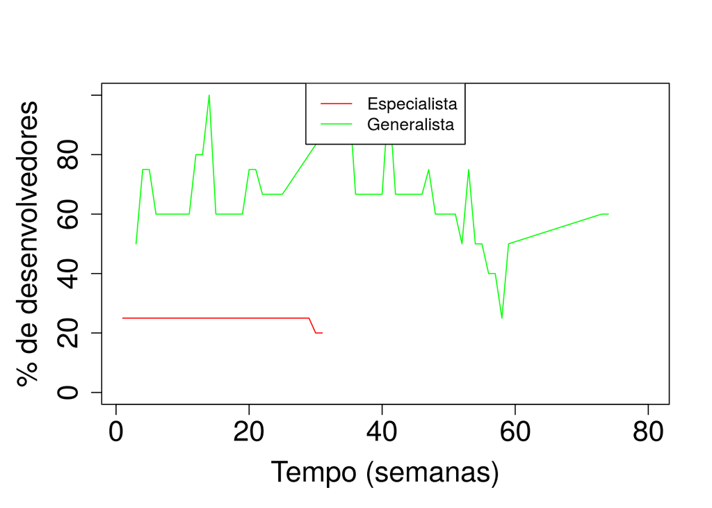

|  | esp | gen |
| --- | --- | --- |
| twosided | 0.0667530 | 0.0112313 |
| greater | 0.9666235 | 0.9943844 |
| less | 0.0333765 | 0.0056156 |

#### SFML

0.5 [1] “

"

#### Evolução dos desenvolvedores ao longo do tempo

( janela 24 semanas, iteracao de 4 semanas) [1] “

"

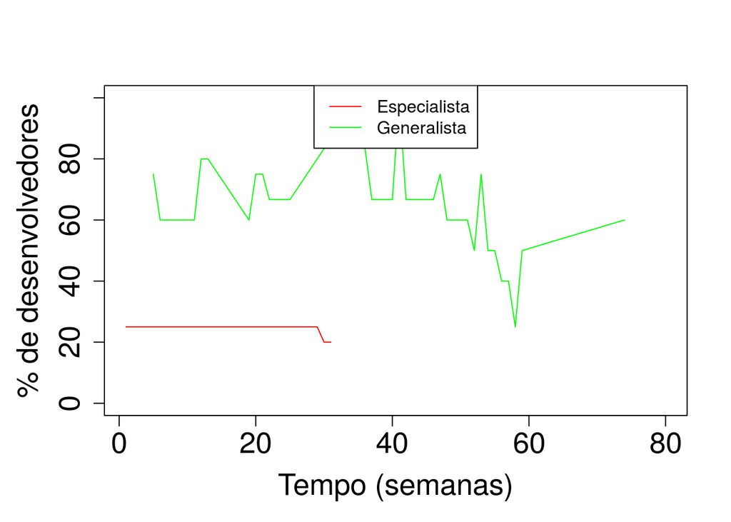

|  | esp | gen |
| --- | --- | --- |
| twosided | 0.0501862 | 0.0061383 |
| greater | 0.9749069 | 0.9969308 |
| less | 0.0250931 | 0.0030692 |

#### Coco2dx

0.1 [1] “

"

#### Evolução dos desenvolvedores ao longo do tempo

( janela 24 semanas, iteracao de 4 semanas) [1] “

"

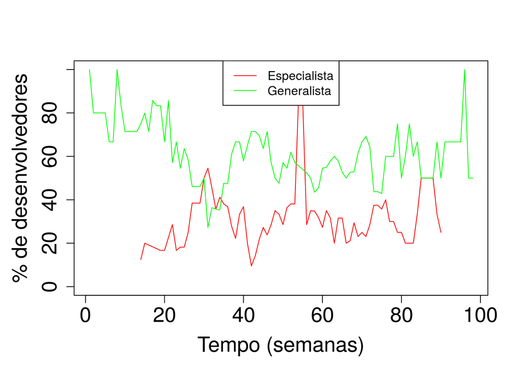

|  | esp | gen |
| --- | --- | --- |
| twosided | 0.227358 | 0.001144 |
| greater | 0.113679 | 0.999428 |
| less | 0.886321 | 0.000572 |

#### Coco2dx

0.2 [1] “

"

#### Evolução dos desenvolvedores ao longo do tempo

( janela 24 semanas, iteracao de 4 semanas) [1] “

"

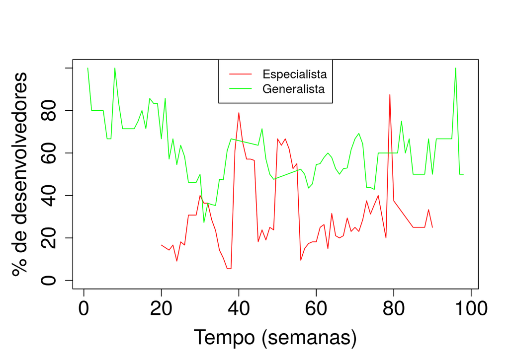

|  | esp | gen |
| --- | --- | --- |
| twosided | 0.1360064 | 0.0032029 |
| greater | 0.0680032 | 0.9983985 |
| less | 0.9319968 | 0.0016015 |

#### Coco2dx

0.3 [1] “

"

#### Evolução dos desenvolvedores ao longo do tempo

( janela 24 semanas, iteracao de 4 semanas) [1] “

"

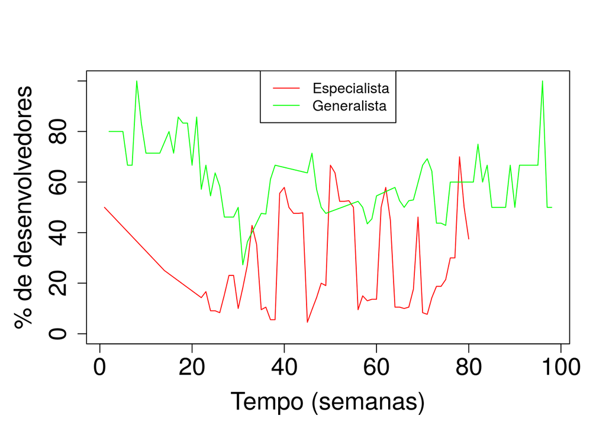

|  | esp | gen |
| --- | --- | --- |
| twosided | 0.3011930 | 0.0028839 |
| greater | 0.1505965 | 0.9985581 |
| less | 0.8494035 | 0.0014419 |

#### Coco2dx

0.4 [1] “

"

#### Evolução dos desenvolvedores ao longo do tempo

( janela 24 semanas, iteracao de 4 semanas) [1] “

"

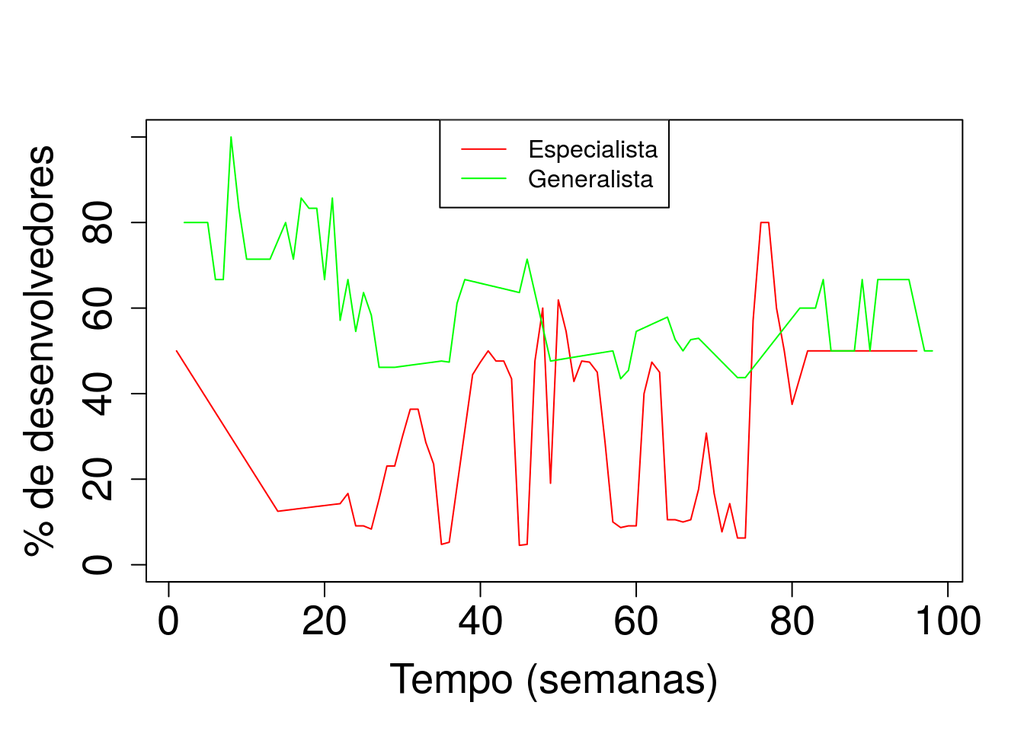

|  | esp | gen |
| --- | --- | --- |
| twosided | 0.1164696 | 0.0000529 |
| greater | 0.0582348 | 0.9999735 |
| less | 0.9417652 | 0.0000265 |

#### Coco2dx

0.5 [1] “

"

#### Evolução dos desenvolvedores ao longo do tempo

( janela 24 semanas, iteracao de 4 semanas) [1] “

"

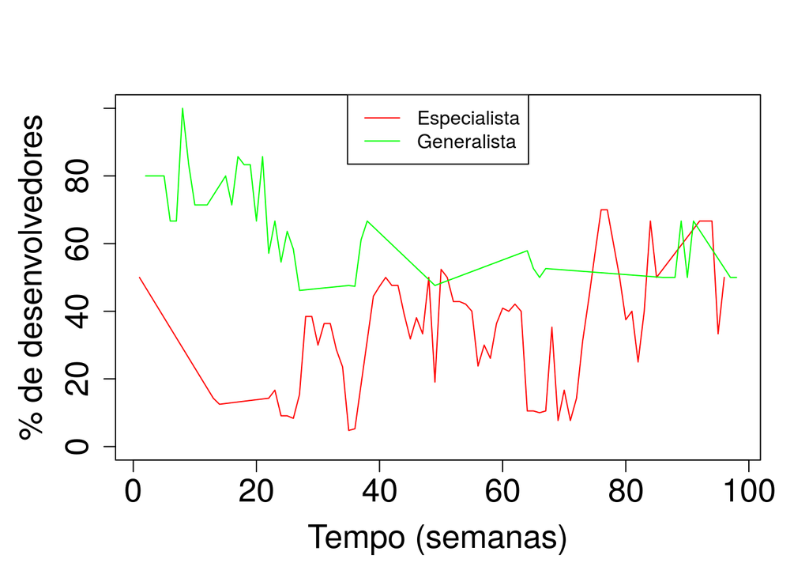

|  | esp | gen |
| --- | --- | --- |
| twosided | 0.0018948 | 0.0000037 |
| greater | 0.0009474 | 0.9999982 |
| less | 0.9990526 | 0.0000018 |